# javi_proyecto

# Introducción

En esta parte vamos a intentar resolver las siguientes preguntas:

- **P1.** ¿Existe correspondencia entre la tipología del punto de estacionamiento y su número de plazas? ¿Dónde hay **atomización** (muchos puntos de pocas plazas) y dónde **macroaparcamientos**?
- **P2.** ¿Dónde se concentran los **desiertos** de estacionamiento ciclista? ¿Estos desiertos están cubiertos por otros transportes?

```r
DIR_DATOS      <- "../data"
CRS_M          <- 25830                       # ETRS89 / UTM 30N (metros) deformacion de La Tierra
UMBRAL         <- c(Valenbisi = 300, EMT = 300, FGV = 500)   # metros
BUFFER_BORDE   <- 1000                        # corrección del
COL_CLASE <- c(Atomizado = "#6250d6", Macroaparcamiento = "#eda100",
               Intermedio = "grey75", `Menos de 3 estaciones` = "grey95")
COL_MODO     <- c(Valenbisi = "#2a78d6", EMT = "#E2001A", FGV = "#FCD116")
HEX_M          <- 50                       # distancia entre lados opuestos del hexágono
MODOS <- c('Valenbisi', 'EMT', 'FGV')
```

Cargamos los datos que necesitamos. Como vamos a calcular distancias transformamos los datos de longitud y latitud a UTM 30N para poder usar metros.

```r
valenbisi <- st_read(file.path(DIR_DATOS, "valenbisi.geojson"), quiet = TRUE) %>% st_transform(CRS_M)
#sapply(valenbisi, function(x) class(x)[1])

emt <- st_read(file.path(DIR_DATOS, "emt.geojson"), quiet = TRUE) %>% st_transform(CRS_M)
#head(emt)
fgv <- st_read(file.path(DIR_DATOS, "fgv_paradas.geojson"), quiet = TRUE) %>% st_transform(CRS_M)

barrios <- st_read(file.path(DIR_DATOS, "geom_barrios.geojson"), quiet = TRUE) %>% st_transform(CRS_M)

distritos <- st_read(file.path(DIR_DATOS, "geom_distritos.geojson"), quiet = TRUE) %>% st_transform(CRS_M)
```

Valenbisi solo existe dentro de València, mientras que EMT y FGV tienen paradas fuera del término municipal. Las mantenemos porque una parada de fuera puede dar servicio a un punto de dentro: si las quitáramos, aparecerían desiertos falsos junto al límite municipal.

```r
municipio <- st_union(distritos)

vb_fuera <- sum(lengths(st_intersects(valenbisi, municipio)) == 0)
cat('Hay', vb_fuera, 'paradas de Valenbisi fuera de València.\n')
```

```
## Hay 0 paradas de Valenbisi fuera de València.
```

```r
emt_fuera <- sum(lengths(st_intersects(emt, municipio)) == 0)
cat('Hay', emt_fuera, 'paradas de EMT fuera de València.\n')
```

```
## Hay 36 paradas de EMT fuera de València.
```

```r
fgv_fuera <- sum(lengths(st_intersects(fgv, municipio)) == 0)
cat('Hay', fgv_fuera, 'paradas de FGV fuera de València.\n')
```

```
## Hay 80 paradas de FGV fuera de València.
```

# Datos tidy

Notamos que los códigos de barrio y de distrito en los dataframes de *barrios* y *distritos* están en formato chr. Además los `NA` que teníamos en ambos data frames se refieren porque no están calculadas las áreas. Entonces, decidimos convertir a entero y recalcular las áreas a partir de los polígonos.

```r
barrios %<>%
  transmute(coddistrit = as.integer(coddistrit),coddistbar = as.integer(coddistbar), codbarrio = as.integer(codbarrio), area_km2 = as.numeric(st_area(geometry)) / 1e6, nombre)
```

```r
distritos %<>%
  transmute(coddistrit = as.integer(coddistrit), area_km2 = as.numeric(st_area(geometry)) / 1e6, nombre)
```

```r
valenbisi %<>% #nos quedamos solo con el número de plazas y el id
  transmute(id= as.character(number),plazas= as.integer(total))
```

Ahora, unimos todas las paradas en un dataframe distinguiendo mediante factores los tipos de transporte

```r
paradas <- bind_rows(
  valenbisi %>% transmute(modo = "Valenbisi", id),
  emt       %>% transmute(modo = "EMT", id = as.character(id_parada)),
  fgv       %>% transmute(modo = "FGV", id = as.character(codigo))
) %>%
  mutate(modo = factor(modo, levels = MODOS))
table(paradas$modo)
```

```
##
## Valenbisi       EMT       FGV
##       273      1155       143
```

Veamos cuales distritos tienen al menos una estación de Valenbisi para poder establecer la frontera de nuestro mapa

```r
# Distritos que tienen al menos una estación Valenbisi
vb_distrito <- st_join(valenbisi, distritos["coddistrit"]) #comprueba si el punto valenbisi está dentro del polígono del distrito y añade el código del distrito

DISTRITOS_DOMINIO <- sort(unique(vb_distrito$coddistrit))
cat('Los distritos',distritos %>% filter(!coddistrit %in% DISTRITOS_DOMINIO) %>%pull(nombre) %>% unique())
```

```
## Los distritos POBLATS DEL SUD POBLATS DEL NORD
```

```r
dominio      <- distritos %>% filter(coddistrit %in% DISTRITOS_DOMINIO) %>% st_union()
zona_calculo <- st_buffer(dominio, BUFFER_BORDE) #nos crea un polígono con un borde
```

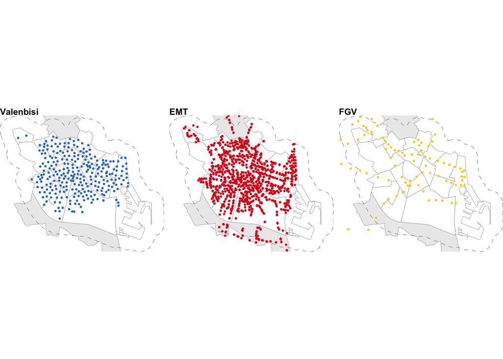

```r
distritos_mapa <- distritos %>% mutate(dentro = coddistrit %in% DISTRITOS_DOMINIO)
caja <- st_bbox(zona_calculo)

ggplot() +
  geom_sf(data = distritos_mapa, aes(fill = dentro), colour = "grey75", linewidth = 0.25) +
  geom_sf(data = st_sf(geometry = zona_calculo), fill = NA, colour = "grey50", linetype = "dashed") +
  geom_sf(data = paradas, aes(colour = modo), size = 0.45, show.legend = FALSE) +
  facet_wrap(~ modo) +
  scale_fill_manual(values = c(`TRUE` = "white", `FALSE` = "grey92"), guide = "none") +
  scale_colour_manual(values = COL_MODO) +
  coord_sf(xlim = caja[c("xmin", "xmax")], ylim = caja[c("ymin", "ymax")], expand = FALSE) +
  theme_void() +
  theme(strip.text = element_text(face = "bold", hjust = 0))
```

## Atomización

En este apartado estudiamos cómo se reparte la capacidad de Valenbisi entre los barrios. Para cada barrio calculamos dos medidas: la densidad de estaciones (estaciones por km²) y el tamaño medio de sus estaciones (plazas por estación). Comparándolas con la mediana de la ciudad distinguimos barrios atomizados (muchos puntos de pocas plazas), barrios con macroaparcamientos (pocos puntos de gran capacidad) y barrios intermedios.

```r
# Estaciones y plazas medias por barrio
vb_barrio <- st_join(valenbisi, barrios["coddistbar"]) %>%
  st_drop_geometry() %>%
  group_by(coddistbar) %>%
  summarise(n_est = n(), plazas_media = mean(plazas))

barrios_dom <- barrios %>%
  filter(coddistrit %in% DISTRITOS_DOMINIO) %>%
  left_join(vb_barrio, by = "coddistbar") %>%
  mutate(n_est = coalesce(n_est, 0L), dens = n_est / area_km2)

# 3 o más estaciones
con3 <- filter(barrios_dom, n_est >= 3)
corte_dens <- median(con3$dens)
corte_tam  <- median(con3$plazas_media)

barrios_dom <- barrios_dom %>%
  mutate(clase = case_when(
    n_est < 3                                     ~ "Menos de 3 estaciones",
    dens >= corte_dens & plazas_media <  corte_tam ~ "Atomizado",
    dens <  corte_dens & plazas_media >= corte_tam ~ "Macroaparcamiento",
    TRUE                                          ~ "Intermedio"))
```

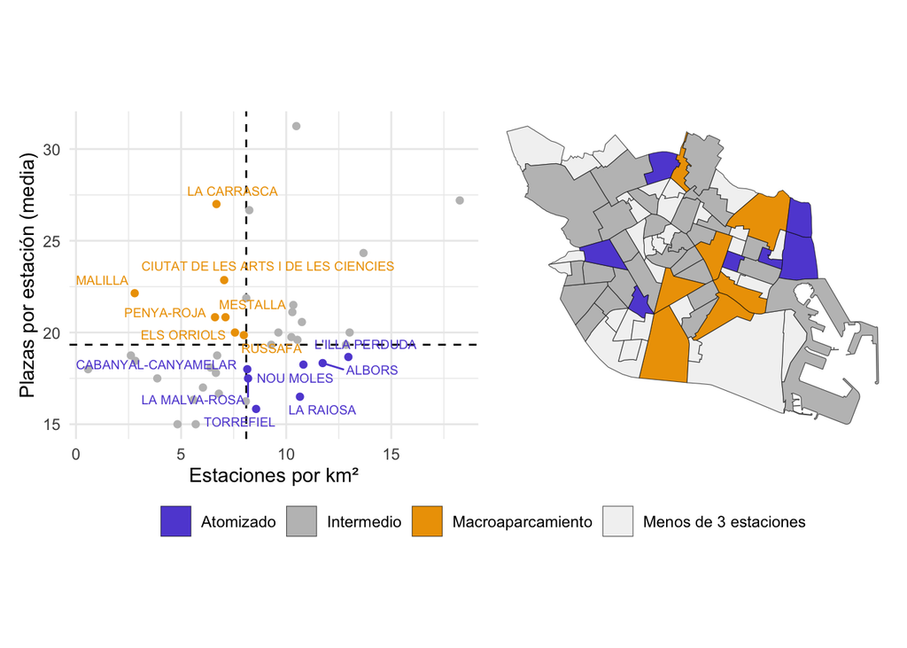

```r
p_a <- ggplot(filter(barrios_dom, n_est >= 3), aes(dens, plazas_media, colour = clase)) +
  geom_vline(xintercept = corte_dens, linetype = 2) +
  geom_hline(yintercept = corte_tam, linetype = 2) +
  geom_point() +
  geom_text_repel(aes(label = nombre), data = ~ filter(.x, clase != "Intermedio"), size = 2.5) +
  labs(x = "Estaciones por km²", y = "Plazas por estación (media)") +
  guides(colour = "none") + theme_minimal()

p_b <- ggplot(barrios_dom) + geom_sf(aes(fill = clase)) + theme_void()

p_a + p_b + plot_layout(guides = "collect") &
  scale_colour_manual(values = COL_CLASE, aesthetics = c("colour", "fill"), name = NULL) &
  theme(legend.position = "bottom")
```

```r
nrow(valenbisi); sum(valenbisi$plazas)
```

```
## [1] 273
```

```
## [1] 5395
```

```r
summary(valenbisi$plazas)
```

```
##    Min. 1st Qu.  Median    Mean 3rd Qu.    Max.
##    9.00   15.00   20.00   19.76   20.00   40.00
```

```r
nrow(barrios_dom); nrow(con3)
```

```
## [1] 72
```

```
## [1] 41
```

```r
corte_dens; corte_tam
```

```
## [1] 8.099066
```

```
## [1] 19.33333
```

De 72 barrios en el dominio, 41 tienen 3 o más estaciones. Las medianas que separan las clases son 8,1 estaciones/km² y 19,3 plazas por estación.

```r
count(st_drop_geometry(barrios_dom), clase)
```

```
##                   clase  n
## 1             Atomizado  7
## 2            Intermedio 27
## 3     Macroaparcamiento  7
## 4 Menos de 3 estaciones 31
```

```r
barrios_dom %>% st_drop_geometry() %>% filter(n_est >= 3) %>%
  group_by(clase) %>% summarise(dens_media = mean(dens), plazas = mean(plazas_media))
```

```
## # A tibble: 3 × 3
##   clase             dens_media plazas
##   <chr>                  <dbl>  <dbl>
## 1 Atomizado              10.2    17.6
## 2 Intermedio              8.24   19.9
## 3 Macroaparcamiento       6.54   21.9
```

En los barrios atomizados, las estaciones tienen de media entre 15,8 y 18,7 plazas. En los de macroaparcamientos, entre 19,9 y 27; el máximo es La Carrasca, donde está el campus de Tarongers.

```r
sum(con3$dens >= 10); sum(con3$dens > 16)
```

```
## [1] 14
```

```
## [1] 1
```

Comparando con la referencia del ITDP (10–16 estaciones/km²), solo 14 de los 41 barrios alcanzan las 10 estaciones/km², y solo uno (Ciutat Universitària) supera las 16

### Rejilla hexagonal

Las paradas son puntos y los barrios son polígonos de tamaños muy dispares (de menos de 0,1 km² a más de 6 km²). Para medir desiertos hace falta un soporte **independiente** de ambos. Se cubre el dominio con una rejilla de hexágonos de 50 m entre lados opuestos y se conservan los hexágonos cuyo centroide cae dentro del dominio. Todos tienen la misma área, por lo que **la proporción de hexágonos es la proporción de superficie**. Se prefieren hexágonos a cuadrados porque sus seis vecinos están a la misma distancia y su menor relación perímetro/área reduce el sesgo de borde.

```r
rejilla <- st_make_grid(dominio, cellsize = HEX_M, square = FALSE)
centros <- st_centroid(rejilla)
dentro  <- lengths(st_within(centros, dominio)) > 0
centros <- centros[dentro]#  nos quedamos con los que tienen el centro dentro del dominio
```

## Desiertos

Ahora es cuando calculamos distancias entre los centros de los hexágonos y cada uno de nuestros medios de transporte

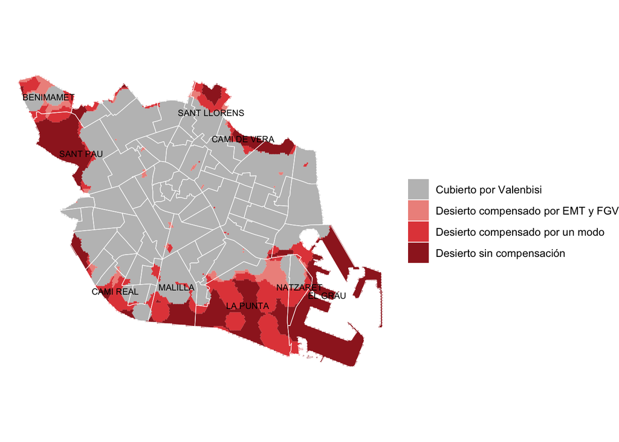

```r
#distancias entre centros de hexágonos y modos de transporte
dist_vb  <- apply(st_distance(centros, filter(paradas, modo == "Valenbisi")), 1, min) #matriz de distancias, y luego aplicas el mínimo por filas (es decir, por centros)
dist_emt <- apply(st_distance(centros, filter(paradas, modo == "EMT")), 1, min)
dist_fgv <- apply(st_distance(centros, filter(paradas, modo == "FGV")), 1, min)
# cobertura
hex <- st_sf(geometry = rejilla[dentro]) %>%
  mutate(V = dist_vb  <= UMBRAL["Valenbisi"],
         E = dist_emt <= UMBRAL["EMT"],
         F = dist_fgv <= UMBRAL["FGV"],
         situacion = case_when(V     ~ "Cubierto por Valenbisi",
                               E & F ~ "Desierto compensado por EMT y FGV",
                               E | F ~ "Desierto compensado por un modo",
                               TRUE  ~ "Desierto sin compensación"))

#barrio de cada hexágono (según su centro) y los 9 barrios con más desierto
hex$coddistbar <- st_join(st_sf(geometry = centros), barrios_dom["coddistbar"])$coddistbar
desierto <- sort(table(hex$coddistbar[!hex$V]), decreasing = TRUE)
top <- names(desierto)[1:9]


ggplot() +
  geom_sf(data = hex%>% group_by(situacion) %>% summarise(), aes(fill = situacion), colour = NA) +
  geom_sf(data = barrios_dom, fill = NA, colour = "white") +
  geom_sf_text(data = filter(barrios_dom, coddistbar %in% top), aes(label = nombre), size = 2.5) +
  scale_fill_manual(values = c("grey75", "#ee938c", "#e34948", "#9e2324"), name = NULL) +
  theme_void()
```

```r
colMeans(st_drop_geometry(hex)[, c("V", "E", "F")]) #qué cubre cada modo
```

```
##         V         E         F
## 0.6654353 0.7703853 0.4876541
```

```r
hex %>% st_drop_geometry() %>% group_by(V) %>% summarise(EMT = mean(E), FGV = mean(F)) #se complementan los medios? NO
```

```
## # A tibble: 2 × 3
##   V       EMT   FGV
##   <lgl> <dbl> <dbl>
## 1 FALSE 0.377 0.146
## 2 TRUE  0.968 0.660
```

```r
sum(desierto[1:9]) / sum(desierto)  # peso de los 9 primeros
```

```
## [1] 0.9138773
```